# Clase 2 - Práctica

Manuel Horn

2025-08-20

Instalar paquetes y librerías correspondientes:

```r
#install.packages('dplyr')
#install.packages('tidyverse')
#install.packages('aplpack')
library(dplyr)
library(tidyverse)
library(ggplot2)
library(aplpack)
```

# Resolución

```r
enc <- read.table('ENNyS_menorA2.txt', header = TRUE)
```

## Ejercicio 1

Primero trabajemos con las variables categóricas (Sexo y Tipo de embarazo)

```r
enc <- enc %>%
  mutate(across(c(Sexo, Tipo_embarazo), as.factor))
```

```r
colSums(is.na(enc)) #no hay datos faltantes
```

```
##          Sexo Tipo_embarazo          Edad          Peso   Perim_encef
##             0             0             0             0             0
##         Talla
##             0
```

```r
attach(enc)
```

```r
table(Sexo)
```

```
## Sexo
## Mujer Varon
##  2729  2947
```

```r
prop.table(table(Sexo))
```

```
## Sexo
##     Mujer     Varon
## 0.4807963 0.5192037
```

```r
table(Tipo_embarazo)
```

```
## Tipo_embarazo
## Multiple   Simple
##      190     5486
```

```r
prop.table(table(Tipo_embarazo))
```

```
## Tipo_embarazo
##   Multiple     Simple
## 0.03347428 0.96652572
```

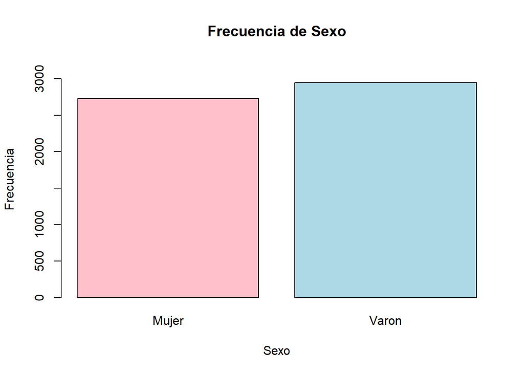

```r
sexo_freq <- table(Sexo)

barplot(sexo_freq,
        main = "Frecuencia de Sexo",
        xlab = "Sexo",
        ylab = "Frecuencia",
        col = c("pink", "lightblue"),
        ylim = c(0, max(sexo_freq) * 1.1)
       )
```

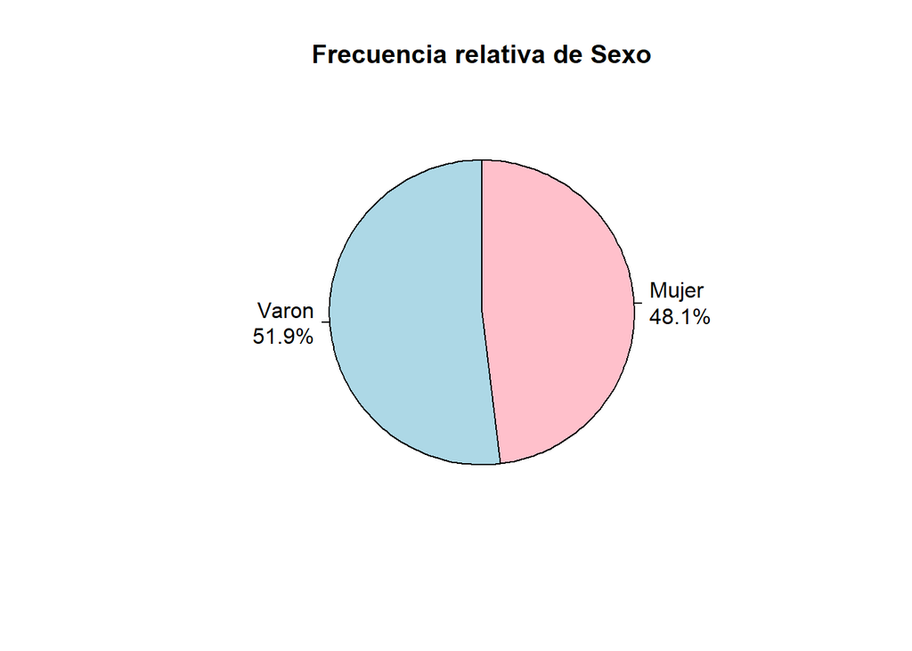

```r
# --- Pie Plot for Sexo ---
pie(prop.table(sexo_freq),
    main = "Frecuencia relativa de Sexo",
    col = c("pink", "lightblue"),
    labels = paste(names(sexo_freq), "\n", round(prop.table(sexo_freq)*100, 1), "%", sep=""),
    clockwise = TRUE)
```

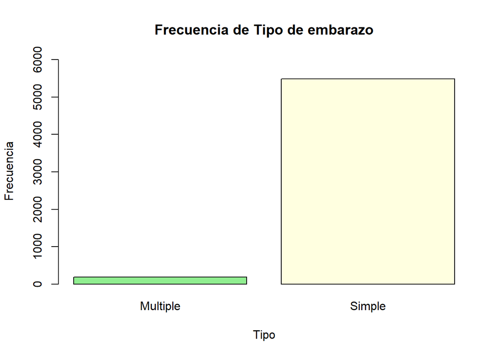

```r
te_freq <- table(Tipo_embarazo)

barplot(te_freq,
        main = "Frecuencia de Tipo de embarazo",
        xlab = "Tipo",
        ylab = "Frecuencia",
        col = c("lightgreen", "lightyellow"),
        ylim = c(0, max(te_freq) * 1.1)
       )
```

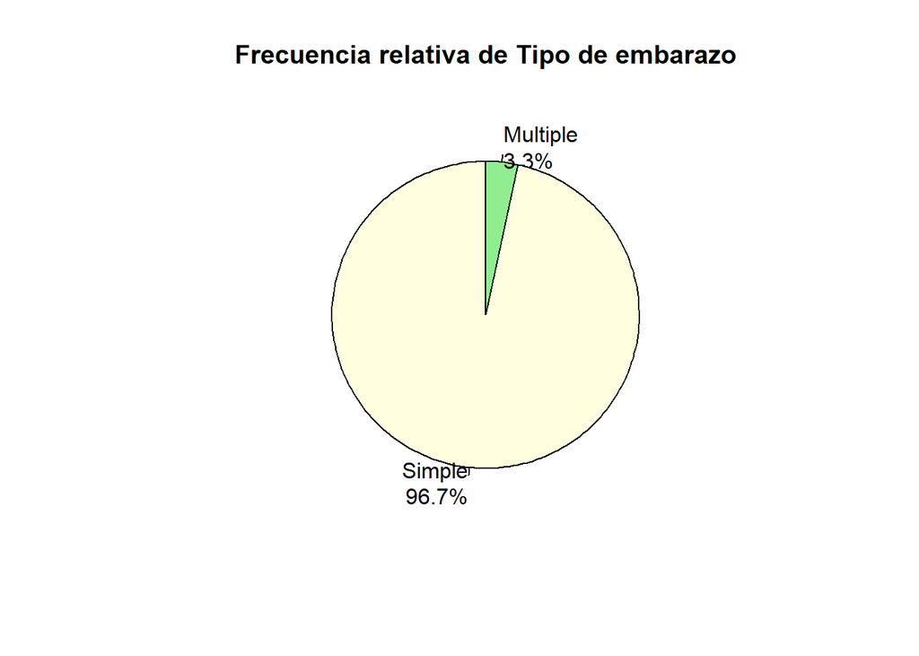

```r
pie(prop.table(te_freq),
    main = "Frecuencia relativa de Tipo de embarazo",
    col = c("lightgreen", "lightyellow"),
    labels = paste(names(te_freq), "\n", round(prop.table(te_freq)*100, 1), "%", sep=""),
    clockwise = TRUE)
```

## Ejercicio 2

Veamos la tabla de contingencia

```r
table(Sexo, Tipo_embarazo)
```

```
##        Tipo_embarazo
## Sexo    Multiple Simple
##   Mujer       91   2638
##   Varon       99   2848
```

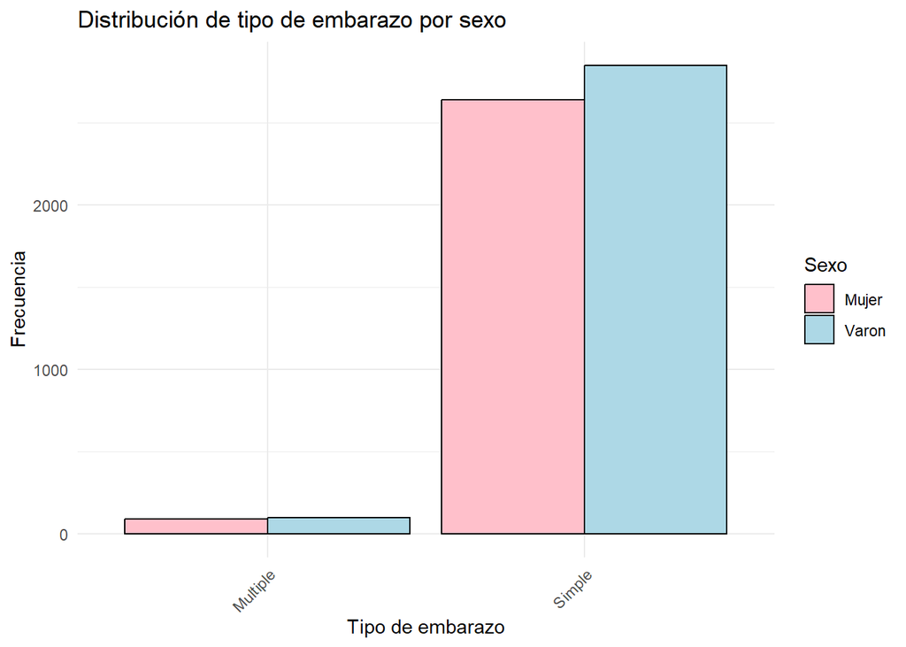

```r
contingency_df <- as.data.frame(table(Sexo, Tipo_embarazo))
colnames(contingency_df) <- c("Sexo", "Tipo_embarazo", "Frecuencia") # Rename columns for clarity

ggplot(contingency_df, aes(x = Tipo_embarazo, y = Frecuencia, fill = Sexo)) +
  geom_bar(stat = "identity", position = "dodge", color = "black") +
  labs(title = "Distribución de tipo de embarazo por sexo",
       x = "Tipo de embarazo",
       y = "Frecuencia",
       fill = "Sexo") +
  scale_fill_manual(values = c("pink", "lightblue")) +
  theme_minimal() +
  theme(axis.text.x = element_text(angle = 45, hjust = 1))
```

## Ejercicio 3

Veamos las variables continuas: Edad, Peso, Perim_encef y Talla

```r
enc_continuas <- enc[,3:length(names(enc))]
```

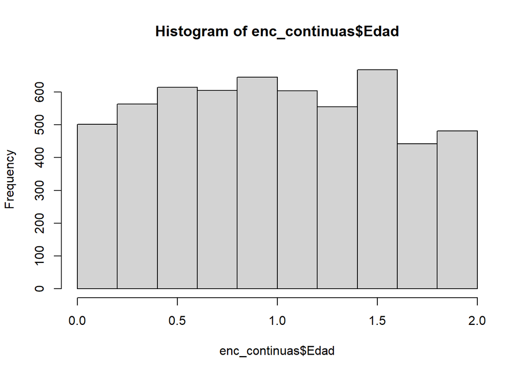

```r
hist(enc_continuas$Edad)
```

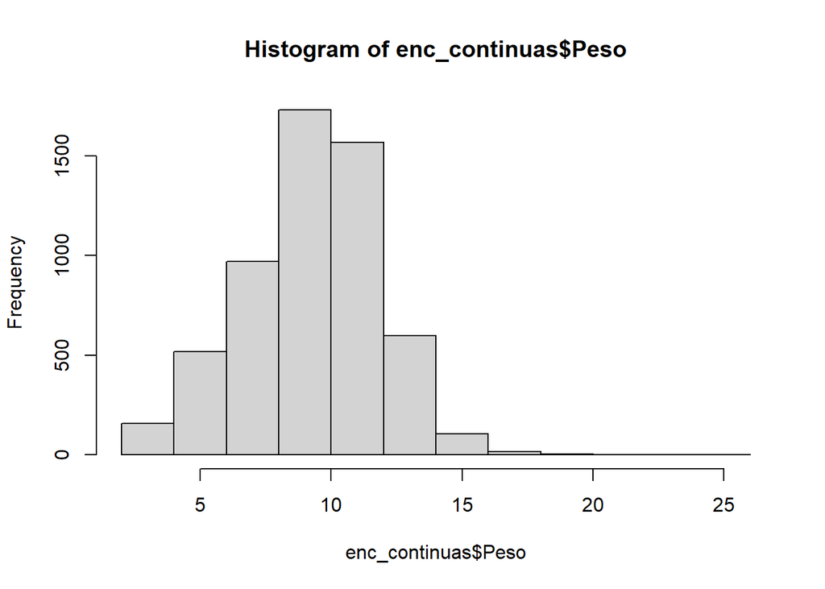

```r
hist(enc_continuas$Peso)
```

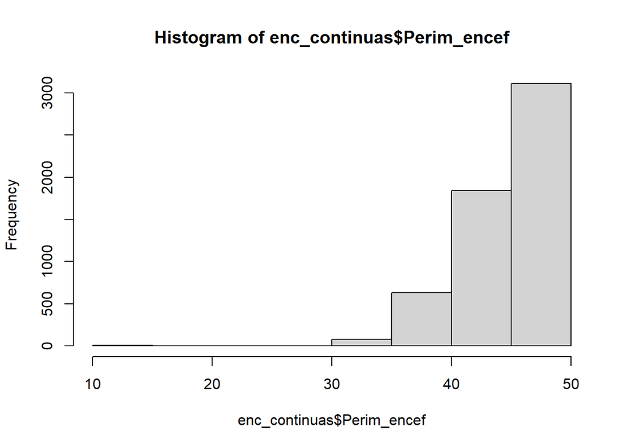

```r
hist(enc_continuas$Perim_encef)
```

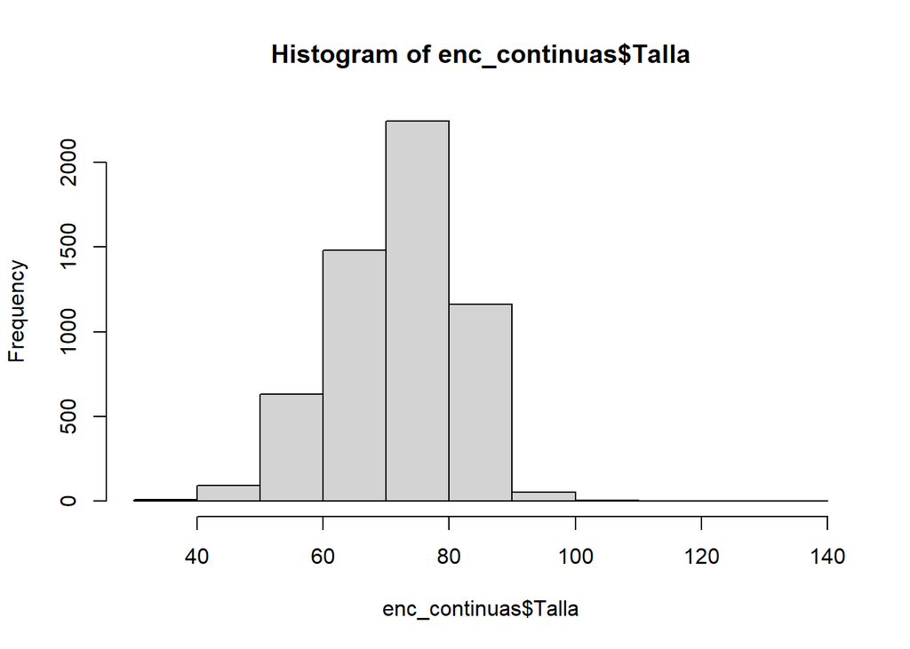

```r
hist(enc_continuas$Talla)
```

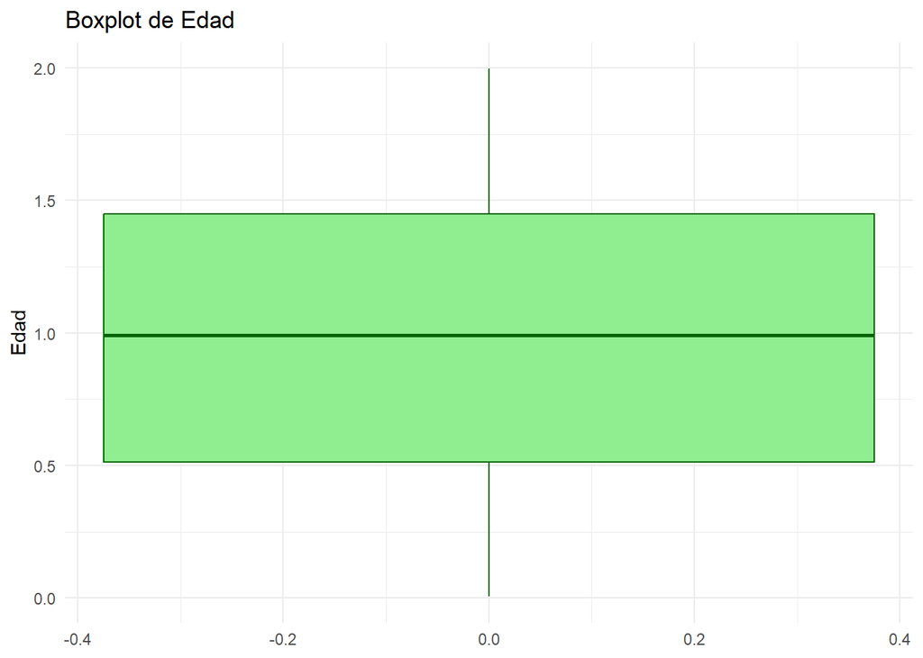

```r
p_boxplot <- ggplot(enc_continuas, aes(y = Edad)) +
    geom_boxplot(fill = "lightgreen", color = "darkgreen", outlier.colour = "red", outlier.size = 2) +
    labs(title = paste("Boxplot de Edad"),
         y = "Edad") +
    theme_minimal()
  print(p_boxplot)
```

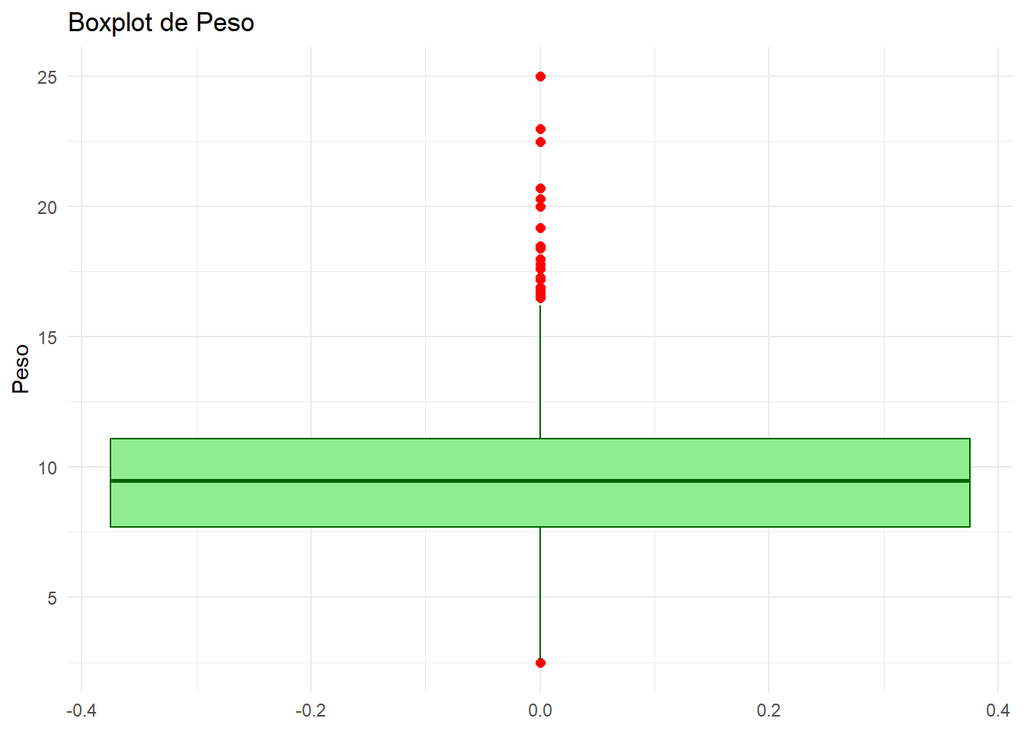

```r
p_boxplot <- ggplot(enc_continuas, aes(y = Peso)) +
    geom_boxplot(fill = "lightgreen", color = "darkgreen", outlier.colour = "red", outlier.size = 2) +
    labs(title = paste("Boxplot de Peso"),
         y = "Peso") +
    theme_minimal()
  print(p_boxplot)
```

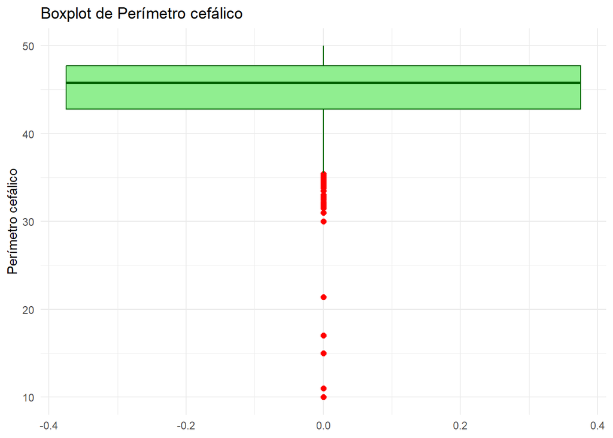

```r
p_boxplot <- ggplot(enc_continuas, aes(y = Perim_encef)) +
    geom_boxplot(fill = "lightgreen", color = "darkgreen", outlier.colour = "red", outlier.size = 2) +
    labs(title = paste("Boxplot de Perímetro cefálico"),
         y = "Perímetro cefálico") +
    theme_minimal()
  print(p_boxplot)
```

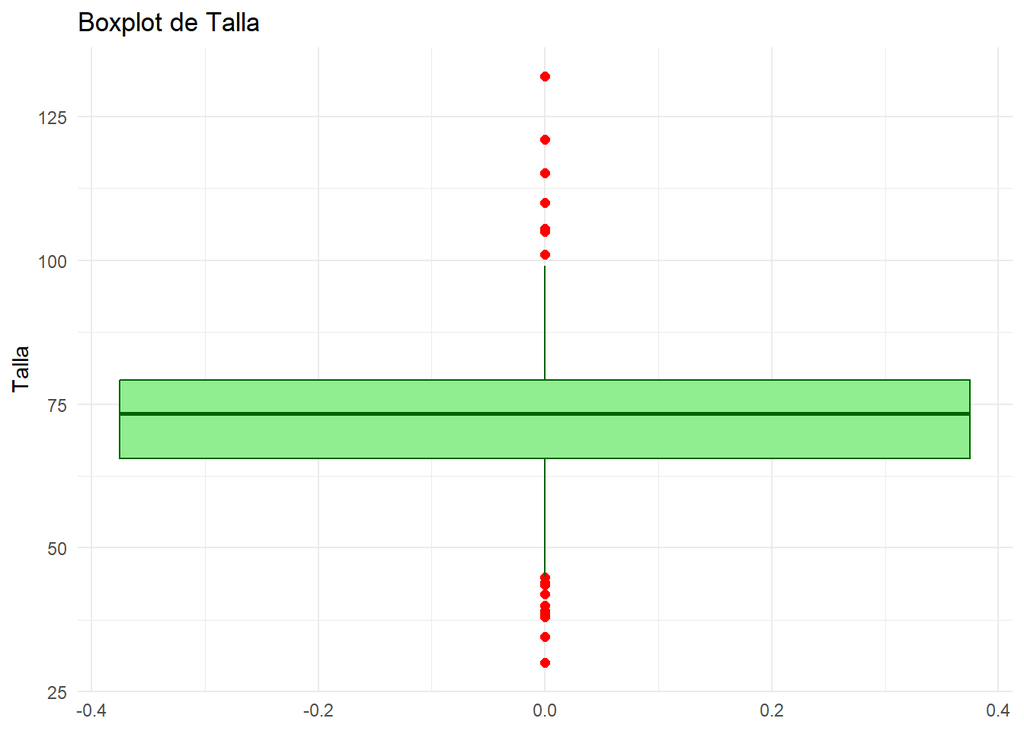

```r
p_boxplot <- ggplot(enc_continuas, aes(y = Talla)) +
    geom_boxplot(fill = "lightgreen", color = "darkgreen", outlier.colour = "red", outlier.size = 2) +
    labs(title = paste("Boxplot de Talla"),
         y = "Talla") +
    theme_minimal()
  print(p_boxplot)
```

Medidas de posición: normalmente usamos summary para ver las medidas resumen de una variable. Hagamos un for loop para las medias podadas

```r
summary(enc_continuas)
```

```
##       Edad               Peso        Perim_encef        Talla
##  Min.   :0.005479   Min.   : 2.48   Min.   :10.00   Min.   : 30.00
##  1st Qu.:0.512329   1st Qu.: 7.68   1st Qu.:42.80   1st Qu.: 65.50
##  Median :0.990411   Median : 9.48   Median :45.80   Median : 73.40
##  Mean   :0.986907   Mean   : 9.29   Mean   :44.85   Mean   : 72.12
##  3rd Qu.:1.449315   3rd Qu.:11.08   3rd Qu.:47.70   3rd Qu.: 79.20
##  Max.   :1.997260   Max.   :24.98   Max.   :50.00   Max.   :132.00
```

```r
for(var in names(enc_continuas)){
  print(paste("Media 0,1 podada", var, ":", mean(enc_continuas[[var]], trim = 0.1, na.rm = TRUE)))
  print(paste("Media 0,2 podada", var, ":", mean(enc_continuas[[var]], trim = 0.2, na.rm = TRUE)))
  print("")
}
```

```
## [1] "Media 0,1 podada Edad : 0.982463823177675"
## [1] "Media 0,2 podada Edad : 0.981552296898708"
## [1] ""
## [1] "Media 0,1 podada Peso : 9.34985909291061"
## [1] "Media 0,2 podada Peso : 9.40881972988843"
## [1] ""
## [1] "Media 0,1 podada Perim_encef : 45.2485028621753"
## [1] "Media 0,2 podada Perim_encef : 45.4443482090429"
## [1] ""
## [1] "Media 0,1 podada Talla : 72.5962549537649"
## [1] "Media 0,2 podada Talla : 72.9070140927774"
## [1] ""
```

Medidas de dispersión:

```r
for(var in names(enc_continuas)){
  print(paste("Desvío estándar", var, ":", sd(enc_continuas[[var]], na.rm = TRUE)))
  print(paste("Distancia intercuartil", var, ":", IQR(enc_continuas[[var]], na.rm = TRUE)))
  print(paste("MAD", var, ":", mad(enc_continuas[[var]], na.rm = TRUE)))
  print("")
}
```

```
## [1] "Desvío estándar Edad : 0.549811732450939"
## [1] "Distancia intercuartil Edad : 0.936986301"
## [1] "MAD Edad : 0.6966189045564"
## [1] ""
## [1] "Desvío estándar Peso : 2.58006096007748"
## [1] "Distancia intercuartil Peso : 3.4"
## [1] "MAD Peso : 2.505594"
## [1] ""
## [1] "Desvío estándar Perim_encef : 3.91916917064148"
## [1] "Distancia intercuartil Perim_encef : 4.90000000000001"
## [1] "MAD Perim_encef : 3.26172"
## [1] ""
## [1] "Desvío estándar Talla : 9.77581501728233"
## [1] "Distancia intercuartil Talla : 13.7"
## [1] "MAD Talla : 9.78515999999999"
## [1] ""
```

Percentiles:

```r
for(var in names(enc_continuas)){
  percentiles <- quantile(enc_continuas[[var]], probs = c(0, 0.1, 0.25, 0.5, 0.75, 0.9, 1), na.rm = TRUE)

  print(paste("Percentiles", var, ":"))
  print(percentiles)
  print(" ")
}
```

```
## [1] "Percentiles Edad :"
##          0%         10%         25%         50%         75%         90%
## 0.005479452 0.227397260 0.512328767 0.990410959 1.449315068 1.747945205
##        100%
## 1.997260274
## [1] " "
## [1] "Percentiles Peso :"
##    0%   10%   25%   50%   75%   90%  100%
##  2.48  5.78  7.68  9.48 11.08 12.38 24.98
## [1] " "
## [1] "Percentiles Perim_encef :"
##   0%  10%  25%  50%  75%  90% 100%
## 10.0 39.4 42.8 45.8 47.7 49.0 50.0
## [1] " "
## [1] "Percentiles Talla :"
##    0%   10%   25%   50%   75%   90%  100%
##  30.0  58.0  65.5  73.4  79.2  83.5 132.0
## [1] " "
```

QQ-plots

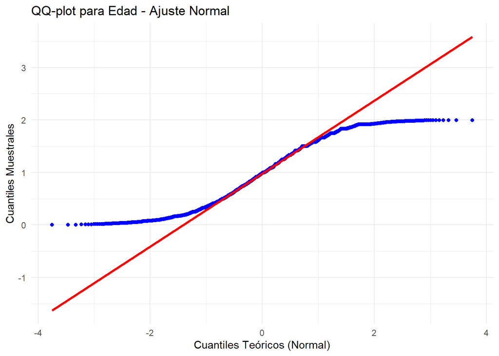

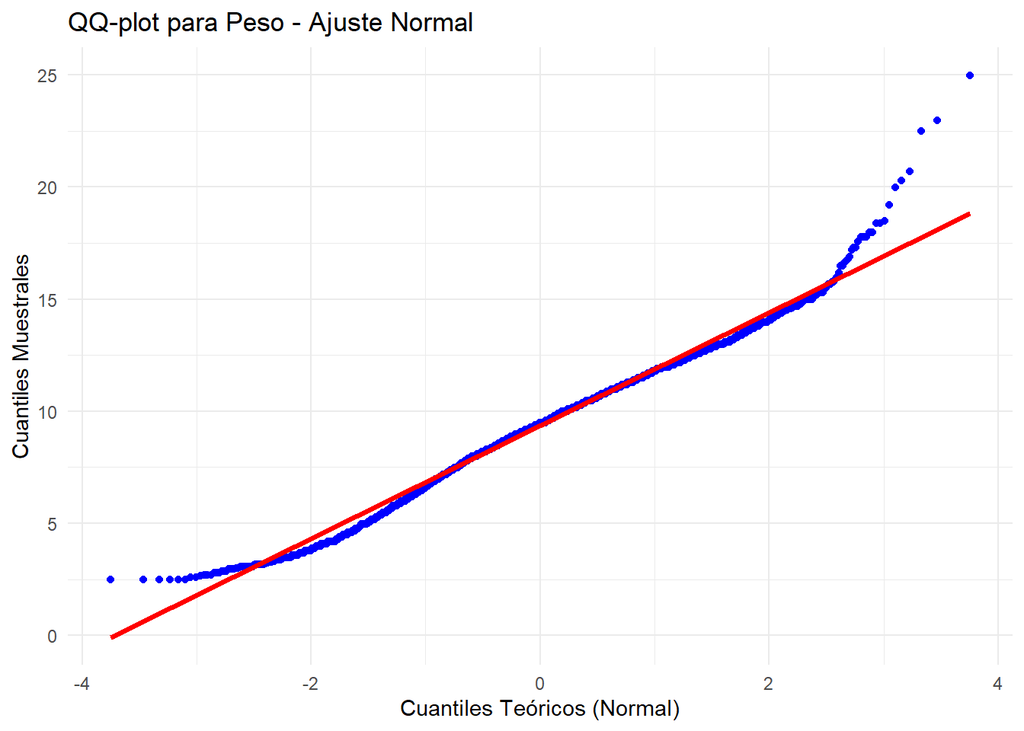

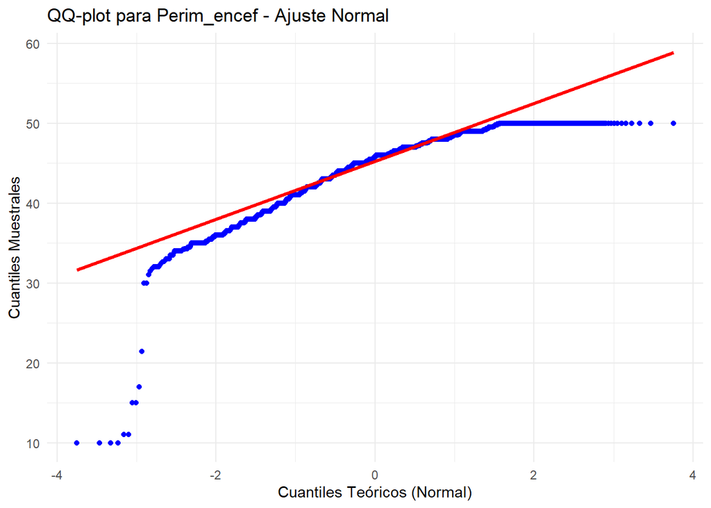

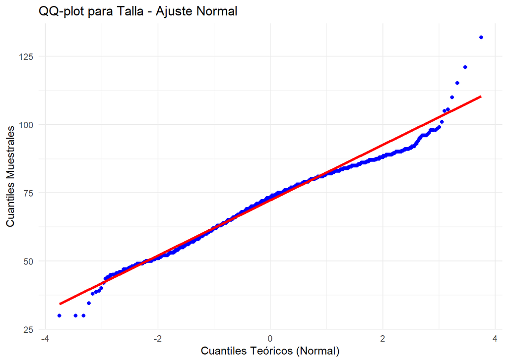

```r
for(var in names(enc_continuas)){
  p_qqnorm <- ggplot(enc_continuas, aes(sample = .data[[var]])) +
    stat_qq(color = "blue", size = 1.5) +              # Puntos de los cuantiles muestrales
    stat_qq_line(color = "red", size = 1.2) +          # Línea de referencia para ajuste normal (cuantiles teóricos)
    labs(title = paste("QQ-plot para", var, "- Ajuste Normal"),
         x = "Cuantiles Teóricos (Normal)",
         y = "Cuantiles Muestrales") +
    theme_minimal()

  # Imprimir el gráfico inmediatamente
  print(p_qqnorm)
}
```

## Ejercicio 4

Extra: hagamos bagplots

Los bagplots sirven para ver la distribución conjunta de dos variables. Son análogos a los boxplots en una variable. En el gráfico podemos ver que el centro de la figura es la mediana de la distribución conjunta. Esta se construye tomando el punto que aproximadamente deja el 50% de los datos de ambos lados si trazamos varias rectas en varias direcciones, pasando por ese punto.

El polígono azul contiene el 50% de los datos (correspondiente a la caja en el boxplot) y el polígono celeste corresponde a los datos dentro de 1.5*IQR en todas las direcciones (sirve para definir datos atípicos en dos dimensiones).

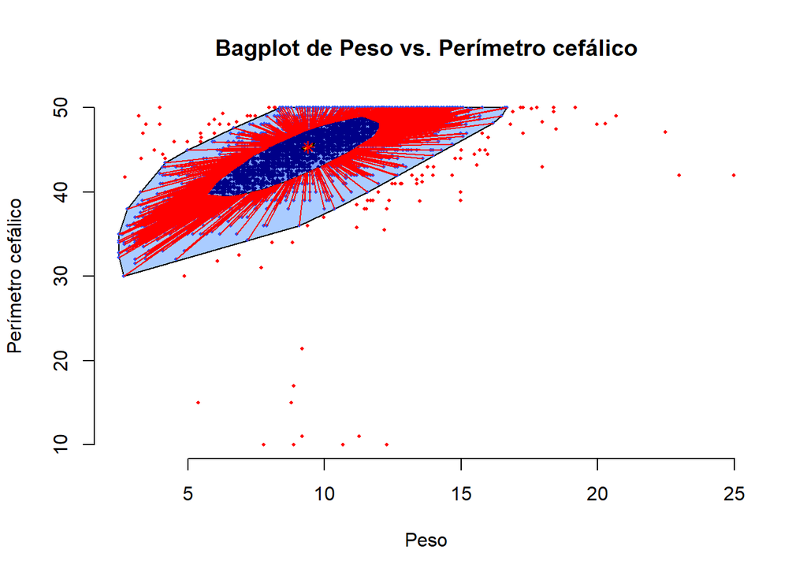

```r
bagplot(enc_continuas$Peso, enc_continuas$Perim_encef,
        xlab = 'Peso',
        ylab = 'Perímetro cefálico',
        main = "Bagplot de Peso vs. Perímetro cefálico",
        #col = c("lightblue", "salmon")
       )
```

## Ejercicio 5

Por último, boxplots por sexo

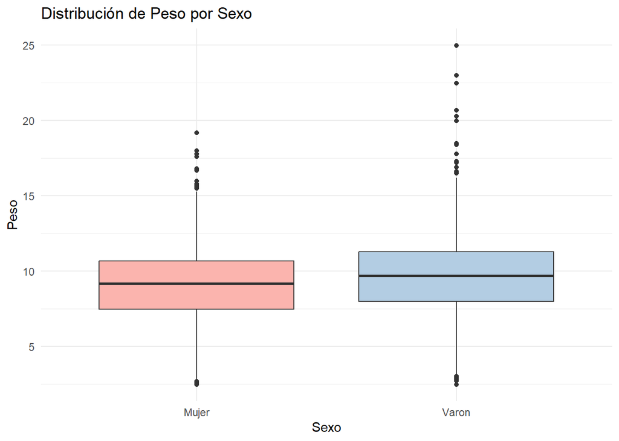

```r
ggplot(enc_continuas, aes(x = Sexo, y = Peso, fill = Sexo)) +
  geom_boxplot() +                                    # Dibuja las cajas (boxplot)
  labs(title = "Distribución de Peso por Sexo",      # Título del gráfico
       x = "Sexo",                                    # Etiqueta del eje X
       y = "Peso") +                                  # Etiqueta del eje Y
  scale_fill_brewer(palette = "Pastel1") +            # Paleta de colores para las cajas (opcional)
  theme_minimal() +                                   # Tema limpio para el gráfico
  theme(legend.position = "none")
```

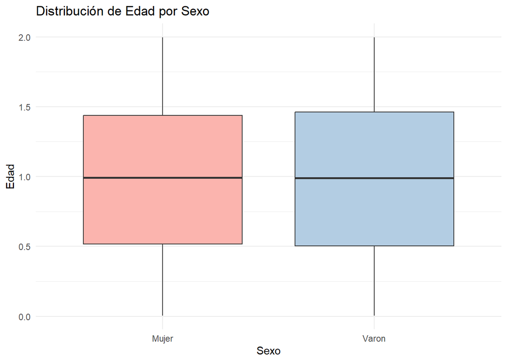

```r
ggplot(enc_continuas, aes(x = Sexo, y = Edad, fill = Sexo)) +
  geom_boxplot() +                                    # Dibuja las cajas (boxplot)
  labs(title = "Distribución de Edad por Sexo",      # Título del gráfico
       x = "Sexo",                                    # Etiqueta del eje X
       y = "Edad") +                                  # Etiqueta del eje Y
  scale_fill_brewer(palette = "Pastel1") +            # Paleta de colores para las cajas (opcional)
  theme_minimal() +                                   # Tema limpio para el gráfico
  theme(legend.position = "none")
```

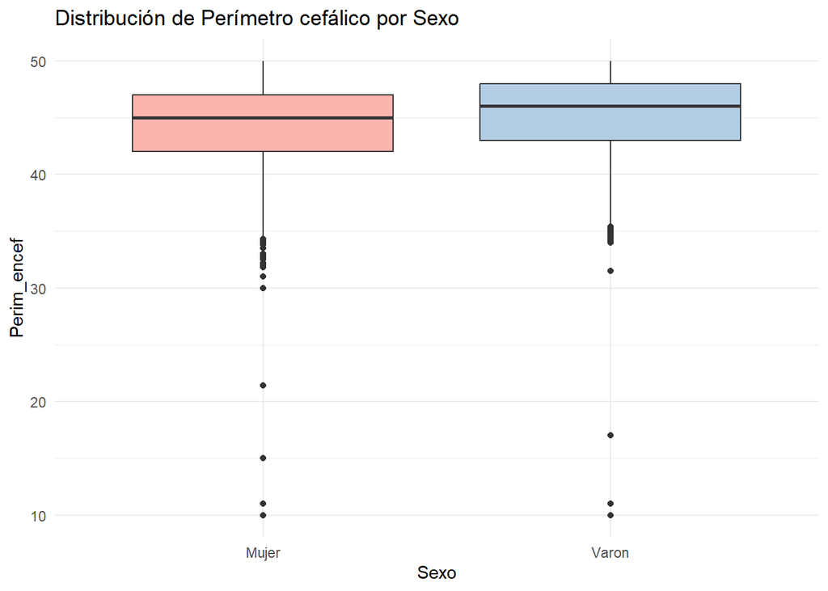

```r
ggplot(enc_continuas, aes(x = Sexo, y = Perim_encef, fill = Sexo)) +
  geom_boxplot() +                                    # Dibuja las cajas (boxplot)
  labs(title = "Distribución de Perímetro cefálico por Sexo",      # Título del gráfico
       x = "Sexo",                                    # Etiqueta del eje X
       y = "Perim_encef") +                                  # Etiqueta del eje Y
  scale_fill_brewer(palette = "Pastel1") +            # Paleta de colores para las cajas (opcional)
  theme_minimal() +                                   # Tema limpio para el gráfico
  theme(legend.position = "none")
```